# Practical machine learning Course Project

Michal Pluta

January 27‚ 2018

# Abstract

Using devices such as Jawbone Up, Nike FuelBand, and Fitbit it is now possible to collect a large amount of data about personal activity relatively inexpensively. These type of devices are part of the quantified self movement – a group of enthusiasts who take measurements about themselves regularly to improve their health, to find patterns in their behavior, or because they are tech geeks. One thing that people regularly do is quantify how much of a particular activity they do, but they rarely quantify how well they do it.

The goal of this projectis to predict the manner in which they did the exercise (“class” variable).

# Data Sets

The training data for this project are available here:

- https://d396qusza40orc.cloudfront.net/predmachlearn/pml-training.csv

The test data are available here:

- https://d396qusza40orc.cloudfront.net/predmachlearn/pml-testing.csv

The data for this project come from this source:

- http://groupware.les.inf.puc-rio.br/har.

The test data will be used for final verification.

# Environemt preparation

Loading necessary libraries and setting seed.

```r
library(foreach)
library(caret)
# parallel processing
library(parallel)
library(doParallel)

set.seed(3524)

cluster <- makeCluster(detectCores() - 1) # convention to leave 1 core for OS
registerDoParallel(cluster)
```

# Loading data

```r
#trainDS <- read.csv("https://d396qusza40orc.cloudfront.net/predmachlearn/pml-training.csv")
#finalTestDS <- read.csv("https://d396qusza40orc.cloudfront.net/predmachlearn/pml-testing.csv")
trainDS <- read.csv("pml-training.csv")
finalTestDS <- read.csv("pml-testing.csv")
```

Loaded data sets overview:

| Data set | Number of observations | Number of variables |
| --- | --- | --- |
| trainsDS | 19622 | 160 |
| finalTestDS | 20 | 160 |

Info: finalTestDS will be used for final project verification

# Splitting training set

Training data set is splitted into: train and test, accordingly 80% and 20% of data.

```r
inTrain <- createDataPartition(trainDS$classe, p = 0.8, list = FALSE)
train <- trainDS[inTrain, ]
test <- trainDS[-inTrain, ]
```

Splitting overview:

| Data set | Number of observations | Number of variables |
| --- | --- | --- |
| train | 15699 | 160 |
| test | 3923 | 160 |

# Cleaning data

## Removing non-significant variables

The following variables will be removed from train and test dataset, since they have not impact for the outcome ‘classe’: X, user_name, raw_timestamp_part_1, raw_timestamp_part_2, cvtd_timestamp, new_window, num_window

```r
train <- train[, -c(1:7)]
test <- test[, -c(1:7)]
```

## Removing variables with nearly zero variance

```r
nzv = nearZeroVar(train)
train <- train[, -nzv]
test <- test[, -nzv]
```

## Removing variables whith NA most values

```r
nullValues <- sapply(train, function(x) mean(is.na(x))) > 0.95
train <- train[, nullValues==FALSE]
test <- test[, nullValues==FALSE]
```

## Cleaning overview

| Data set | Number of observations | Number of variables |
| --- | --- | --- |
| train | 15699 | 53 |
| test | 3923 | 53 |

# Building Model

## Selected Model

To test the best accuracy two model will be compared:

- rpart - Classification Tree
- rf - Random Forest

5-Fold Cross Validation method will be used for trainControl within caret package.

## Model Comparision

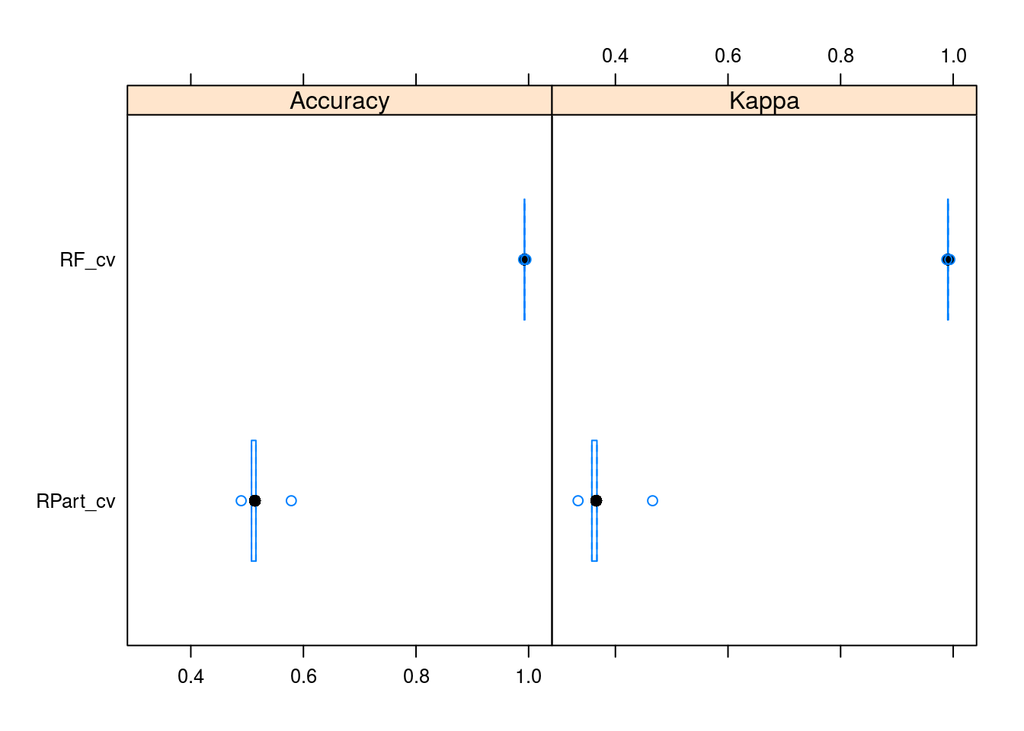

```r
#trainControl=CV
controlCV <- trainControl(method = "cv",number = 5, allowParallel = TRUE)
modelRFControlCv <- train(classe ~ ., data = train, method = "rf", trControl = controlCV)
modelRPartControlCv <- train(classe ~ ., data = train, method = "rpart", trControl = controlCV)

# collect resamples
resultsCV <- resamples(list(RF_cv=modelRFControlCv, RPart_cv=modelRPartControlCv))
# boxplots of results
bwplot(resultsCV)
```

```r
stopCluster(cluster)
```

Model Classification Tree can not be used for prediction. Accuracy is around 0.5 Random Forest Model will be used for further analyse.

## Prediction

```r
# Random Forest
print(modelRFControlCv)
```

```
## Random Forest
##
## 15699 samples
##    52 predictors
##     5 classes: 'A', 'B', 'C', 'D', 'E'
##
## No pre-processing
## Resampling: Cross-Validated (5 fold)
##
## Summary of sample sizes: 12559, 12561, 12558, 12558, 12560
##
## Resampling results across tuning parameters:
##
##   mtry  Accuracy   Kappa      Accuracy SD  Kappa SD
##    2    0.9927382  0.9908136  0.001262940  0.001597467
##   27    0.9928656  0.9909750  0.001504549  0.001903398
##   52    0.9868146  0.9833201  0.001877644  0.002376359
##
## Accuracy was used to select the optimal model using  the largest value.
## The final value used for the model was mtry = 27.
```

```r
# Prediction for test set (20% of trainDS)
predict <- predict(modelRFControlCv, test)

# Prediction result
confusion <- confusionMatrix(test$classe, predict)
confusion
```

```
## Confusion Matrix and Statistics
##
##           Reference
## Prediction    A    B    C    D    E
##          A 1115    1    0    0    0
##          B    6  750    3    0    0
##          C    0    1  683    0    0
##          D    0    0   11  631    1
##          E    0    0    3    0  718
##
## Overall Statistics
##
##                Accuracy : 0.9934
##                  95% CI : (0.9903, 0.9957)
##     No Information Rate : 0.2858
##     P-Value [Acc > NIR] : < 2.2e-16
##
##                   Kappa : 0.9916
##  Mcnemar's Test P-Value : NA
##
## Statistics by Class:
##
##                      Class: A Class: B Class: C Class: D Class: E
## Sensitivity            0.9946   0.9973   0.9757   1.0000   0.9986
## Specificity            0.9996   0.9972   0.9997   0.9964   0.9991
## Pos Pred Value         0.9991   0.9881   0.9985   0.9813   0.9958
## Neg Pred Value         0.9979   0.9994   0.9948   1.0000   0.9997
## Prevalence             0.2858   0.1917   0.1784   0.1608   0.1833
## Detection Rate         0.2842   0.1912   0.1741   0.1608   0.1830
## Detection Prevalence   0.2845   0.1935   0.1744   0.1639   0.1838
## Balanced Accuracy      0.9971   0.9973   0.9877   0.9982   0.9988
```

Accuracy is around 99,3%, so the out-of-sample error is 0,7%.

## Prediction on finalTest DataSet

```r
# Prediction for final test set
predictFinal <- predict(modelRFControlCv, finalTestDS)
predictFinal
```

```
##  [1] B A B A A E D B A A B C B A E E A B B B
## Levels: A B C D E
```